# Human-Robot Interaction

## Tutorial 2: Robot learning part 1: Neural Networks Reminder

**Authors: Pablo Lanillos and Zied Tayeb**

**Date**16/09/2020

```python
#Visualize your python being executed
import sys
sys.executable
```

```
'c:\\users\\u502176\\desktop\\donders\\teaching\\ma-mki70\\code\\hri\\scripts\\python.exe'
```

## Import modules

```python
import numpy as np
import pandas as pd
import seaborn as sns
import matplotlib
import matplotlib.pyplot as plt
import matplotlib.animation as animation
#%matplotlib notebook
```

# 1. What is a neural network?

A neural network takes an input, passes it through multiple layers of hidden neurons (mini-functions with unique coefficients that must be learned), and outputs a prediction representing the combined input of all the neurons. Neural Networks consist of the following components

```
1-) An input layer, x
2-) An arbitrary amount of hidden layers
3-) An output layer, ŷ
4-) A set of weights and biases between each layer, W and b
5-) A choice of activation function for each hidden layer.
```

## 1.1 Example of a neural network architecture: 4-Layer neural network

Let us construct a four-layer network (input, 2-hidden layers, output) Source: [https://towardsdatascience.com/]

```
1-) Input layer - 64 neurons (input image array)
2-)Hidden layer 1 - 128 neurons (arbitrary)
3-) Hidden layer 2 - 128 neurons (arbitrary)
4-) A set of weights and biases between each layer, W and b
5-) Output layer - 10 neurons (output one-hot array)
```

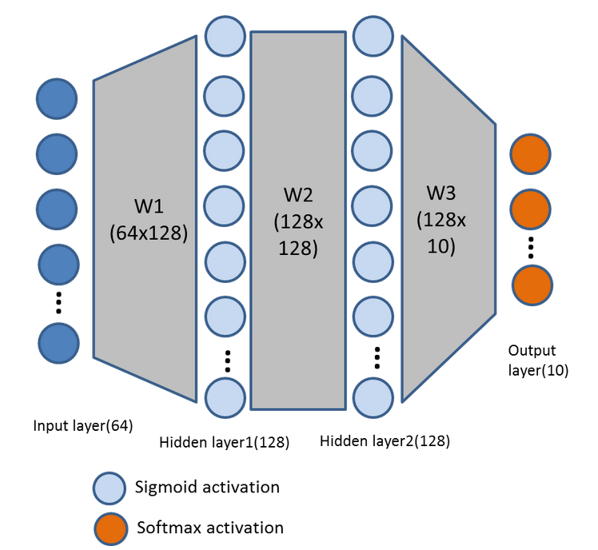

```python
from IPython.display import Image
Image("NN_architecture.png")
```

# Hint

The activation function for the output layer should be **softmax** if you have a **multiclass classification problem**, a **sigmoid** if you have a **binary classification problem** or **linear** if you have a **regression problem**.

## 1.2 Open Questions

```
1-) Do you **all** know the difference between a regression and a classification problem?
2-) Do you know what the bias is used for?
3-) Why do we use activations functions at all?
```

## 2. Activation functions

## 2.1 Sigmoid function

$${\displaystyle f(x)={\frac {1}{1+e^{-x}}}} \hspace{1cm} {\displaystyle f'(x) = f(x)\cdot(1-f(x))}$$

```python
def plot_activation(input_data, func, dfunc, name="sigmoid"):
    plt.figure(figsize=(10,6))
    plt.title(name, fontsize=20, fontweight='bold')
    plt.xlabel('z', fontsize=15)
    plt.ylabel('Activation function value', fontsize=15)
    sns.set_style("whitegrid")
    plt.plot(input_data, func, label="f (z)")
    plt.plot(input_data, dfunc, label="f '(z)")
    plt.legend(loc=4, prop={'size': 15}, frameon=True,shadow=True, facecolor="white", edgecolor="black")
    plt.savefig(name + ".png")
    plt.show()
    return
```

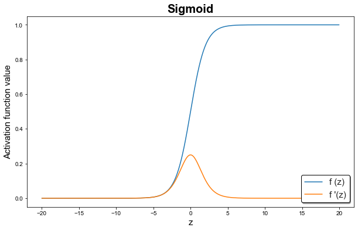

```python
z = np.arange(-20, 20, 0.02)
f = 1/(1 + np.exp(-z))
df = f*(1 - f)
plot_activation(z, f, df, "Sigmoid")
```

## 2.2 ReLU

$${\displaystyle f(x) = \begin{cases} 0 & \text{ if } x<0 \\ x & \text{ if } x\geq x \end{cases}} \hspace{1cm} {\displaystyle f(x) = \begin{cases} 0 & \text{ if } x<0 \\ 1 & \text{ if } x\geq x \end{cases}}$$

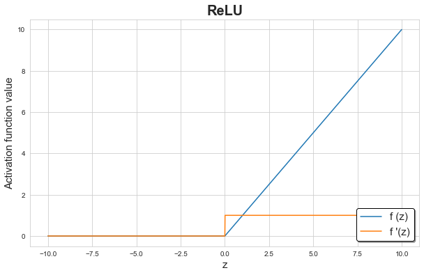

```python
z = np.arange(-10, 10, 0.01)
f = z * (z > 0)
df = 1. * (z > 0)
plot_activation(z, f, df, "ReLU")
```

## 2.3 Tanh

$${\displaystyle f(x) = \operatorname {tgh} x={\frac {\sinh x}{\cosh x}}={\frac {e^{x}-e^{-x}}{e^{x}+e^{-x}}}} \hspace{1cm} {\displaystyle f'(x) = 1 - f(x)^{2}}$$

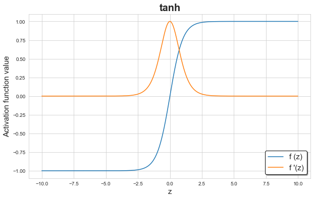

```python
z = np.arange(-10, 10, 0.01)
f = np.tanh(z)
df = 1 - f*f
plot_activation(z, f, df, "tanh")
```

## LeakyReLU

$${\displaystyle f(x) = \begin{cases} 0.01 \cdot x & \text{ if } x<0 \\ x & \text{ if } x\geq x \end{cases}} \hspace{1cm} {\displaystyle f(x) = \begin{cases} 0.01 & \text{ if } x<0 \\ 1 & \text{ if } x\geq x \end{cases}}$$

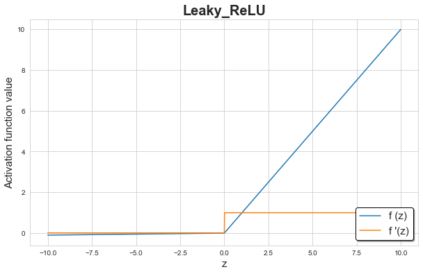

```python
z = np.arange(-10, 10, 0.01)
f = np.where(z > 0, z, z * 0.01)
df = np.where(z > 0, 1, 0.01)
plot_activation(z, f, df, "Leaky_ReLU")
```

## 2.4 Open questions

```
1-) When to use each function?
2-) What are the limitations of each function?
```

# 3. Feed forward part

## 3.1 Initialize the weights and biases

```
1-) Randomly initialize the weights. The values should never be zero but closer to zero.
2-) It is good to have positive as well as negative values so that apart from magnitude, direction also differs.
3-) Normal distribution is a good choice.
4-) Initializing bias vectors to zero is fine.
```

## 3.2 Feed-forward process

$${\displaystyle c={{(input \cdot weights) + bias}}} \hspace{1cm} {\displaystyle a1= f1(c)}$$

### 3.2.1 Example code

```python
def feed_forward(x, Wh, Wo):
    # Hidden layer
    Zh = x * Wh
    H = activation_function(Zh)

    # Output layer
    Zo = H * Wo
    output = activation_function(Zo)
    return output
```

### 3.2.2 Feed forward equations: 4-Layer neural network

$${\displaystyle c1={{(X \cdot w1) + b1}}} \hspace{1cm} {\displaystyle a1= sigmoid(c1)}$$$${\displaystyle c2={{(a1 \cdot w2) + b2}}} \hspace{1cm} {\displaystyle a2= sigmoid(c2)}$$$${\displaystyle c3={{(a2 \cdot w3) + b3}}} \hspace{1cm} {\displaystyle a3= softmax(c3)}$$

# 4. Backpropogation

Back-propagation computes the error from the output of feed-forward and the true value. This error is back-propagated to all the weight matrices through computing gradients in each layer and these weights are updated.

## 4.1 Loss function

Generally speaking, the loss function is designed to show how far we are from the 'ideal' solution.

### 4.1.1 Code

```python
def compute_loss_func(self, y_pred, y_real):
        if self.cost_name=="MSE":
            e=np.mean(np.power(y_real-y_pred, 2))
            e_prime= 2*(y_pred-y_real)/y_real.size
        #−(ylog(p)+(1−y)log(1−p))
        # −∑yo,clog(po,c)
        elif self.cost_name=="cross_entropy":
            n_samples = y_real.shape[0]
            #y_real.argmax(axis=1) returns the indices of
            logp = - np.log(y_pred[np.arange(n_samples), y_real.argmax(axis=1)])
            #log_likelihood = -np.log(p[range(a),y_true])
            e = np.sum(logp)/n_samples
            #p[range(a),y_true] -= 1
            e_prime = 0
        else:
            raise ValueError('Cost function is not supported')
        return e, e_prime
```

### 4.1.2 Binary entropy

M - number of classes (dog, cat, fish)

log - the natural log

y - binary indicator (0 or 1) if class label c is the correct classification for observation o

p - predicted probability observation o is of class c

src: https://ml-cheatsheet.readthedocs.io/en/latest/loss_functions.html

$$-\left(y\log(p) + (1-y)\log(1-p)\right)$$

### 4.1.3 Cross entropy

$$-\sum_{c=1}^My_{o,c}\log(p_{o,c})$$

### 4.1.3 MSE

$$MSE=\frac{1}{n}\sum_{i}^n (y_i - \hat{y_i})^2$$

## 4.2 Backpropogation equation: Example- 4 Layer network

### Equation 1: W3

$$\frac{dcost}{dw3}= \frac{dcost}{da3} \cdot \frac{da3}{dc3} \cdot \frac{dc3}{dw3}$$$$\hspace{1cm}$$

Where:

$${ c3={{(a2 \cdot w3) + b3}}} \hspace{1cm} {a3= softmax(c3)}$$$$\hspace{1cm}$$

1. $$\frac{dc3}{dw3}=a2$$ $$\hspace{1cm}$$
2. $$\frac{da3}{dc3}={dsoftmax(c3)}$$ $$\hspace{1cm}$$
3. $$\frac{dcost}{da3}=\frac{-y}{a3}$$ $$\hspace{1cm}$$

### Hint: Product of cross_entropy' * softmax'= predicted value — real value

### Equation 1: W3

$$\hspace{1cm}$$$$\frac{dcost}{dw3}= {a2} \cdot ({a3-y})$$$$\hspace{1cm}$$

### Update equation: W3

$$\hspace{1cm}$$$${w3}= {w3} - \frac{dcost}{dw3}$$$$\hspace{1cm}$$

with: $$a3\_delta=({a3-y})$$

### Equation 1: b3

$$\frac{dcost}{db3}= \frac{dcost}{da3} \cdot \frac{da3}{dc3} \cdot \frac{dc3}{db3}$$

1. $$\frac{dcost}{da3} \cdot \frac{da3}{dc3}= ({a3-y})$$ $$\hspace{1cm}$$
2. $$\frac{dc3}{db3}=1$$ $$\hspace{1cm}$$

### Equation 1: b3

$$\hspace{1cm}$$$$\frac{dcost}{db3}= ({a3-y})$$

${b3}= {b3} - \frac{dcost}{db3}$

### Equation 2: W2

$$\hspace{1cm}$$$$\frac{dcost}{dw2}= \frac{dcost}{da2} \cdot \frac{da2}{dc2} \cdot \frac{dc2}{dw2}$$

**Where:** $$c2={{(a1\cdot w2) + b2}}$$

$$a2=sigmoid(c2)$$

1. $$\frac{dc2}{dw2}=a1$$ $$\hspace{1cm}$$
2. $$\frac{da2}{dc2}={dsigmoid(c2)}$$

**or**

1. $$\frac{dcost}{da2}=\frac{dcost}{da3}\cdot \frac{da3}{dc3}\cdot \frac{dc3}{da2}= ({a3-y})\cdot{w3}$$

$$\hspace{1cm}$$

**Hint: Product of cross_entropy' * softmax'= predicted value — real value**

### Equation 1: W2

$$\hspace{1cm}$$$$\frac{dcost}{dw2}= {a1} \cdot ({a3-y})\cdot {w3} \cdot {dsigmoid(c2)} $$$$\hspace{1cm}$$

### Update equation: W2

$$\hspace{1cm}$$$${w2}= {w2} - \frac{dcost}{dw2}$$$$\hspace{1cm}$$

### with: $$a2\_delta=(({a3-y})\cdot {w3} \cdot {dsigmoid(c2)})$$

### Equation 2: b2

$$\frac{dcost}{db2}= \frac{dcost}{da2} \cdot \frac{da2}{dc2} \cdot \frac{dc2}{db2}$$

1. $$\frac{dcost}{da3} \cdot \frac{da3}{dc3}= ({a3-y})$$
2. $$\frac{dc3}{db3}=1$$

### Equation 2: b2

$$\frac{dcost}{db3}= ({a3-y})\cdot {w3} \cdot {dsigmoid(c2)}$$

### Update equation: b2

$${b2}= {b2} - \frac{dcost}{db2}$$$${b2}= {b2} - (({a3-y})\cdot {w3} \cdot {dsigmoid(c2)})$$

### Equation 3: W1

$$\frac{dcost}{dw1}= \frac{dcost}{da1} \cdot \frac{da1}{dc1} \cdot \frac{dc1}{dw1}$$$$\hspace{1cm}$$

Where: $$\hspace{1cm}$$ $${c1={(input\cdot w1) + b1}} \hspace{1cm} a1=sigmoid(c1)$$ $$\hspace{1cm}$$

1. $$\frac{dc1}{dw1}=input$$ $$\hspace{1cm}$$
2. $$\frac{da1}{dc1}={dsigmoid(c1)}$$ $$\hspace{1cm}$$

or

1. $$\frac{dcost}{da1}=\frac{dcost}{da2}\cdot \frac{da2}{dc2}\cdot \frac{dc2}{da1}= ({a2\_delta})\cdot{w2}$$ $$\hspace{1cm}$$

### Update equation: W1

$$\hspace{1cm}$$$${w2}= {w1} - \frac{dcost}{dw1}$$$$\hspace{1cm}$$

with: $$a1\_delta=\frac{dcost}{da1} \cdot \frac{da1}{dc1}$$ $$\hspace{1cm}$$

### Update equation: b1

$$\hspace{1cm}$$$${b1}= {b1} - \frac{dcost}{db1}$$$$\hspace{1cm}$$$${b1}= {b1} - (a1\_delta)$$

# Show how neural networks can learn

```python
from IPython.lib.display import YouTubeVideo
YouTubeVideo('nrnxZVEHZCo', width=800,height=400)
```

[video not shown]

# 5. Neural Networks: Summarize the different steps

[figure not shown]

**Figure 2.** Neural network blueprint

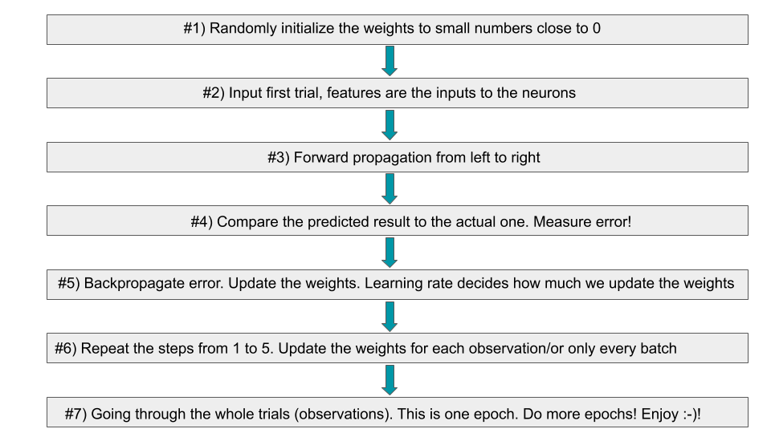

```python
from IPython.display import Image
Image("steps.png")
```

# References:

1- https://towardsdatascience.com/how-to-build-your-own-neural-network-from-scratch-in-python-68998a08e4f6

2- https://ml-cheatsheet.readthedocs.io/en/latest/forwardpropagation.html

3- https://medium.com/

4- https://github.com/miloharper/neural-network-animation

# 6. Example code:

## Python implementation of Neural networks without libraries

# Neural Network class: Classification problem

```python
class neural_networks:

        def __init__(self, x, y, layers=[128, 128,10], **kwargs):

            #self.activation_name = kwargs.pop('activation_name', 'ReLu')
            self.cost_name = kwargs.pop('cost_function_name', 'cross_entropy')
            self.input= x
            self.output=y
            #learning rate
            self.learning_rate=0.5
            super(neural_networks, self).__init__()
            #the size of the input
            self.input_size=x.shape[1]
            #the size of the output
            self.output_size=y.shape[1]
             #initialize the weights for one layer, matrix (input_layer, output_layer)
            self.weights = [np.random.randn(self.input_size, layers[0])]
            #initialize the biases for one layer, vector (1, output_layer)
            self.biases=[np.zeros((1,layers[0]))]

            for i in range (len(layers)-1):
                self.weights.append(np.random.randn(layers[i], layers[i+1]))
                self.biases.append(np.zeros((1,layers[i+1])))
            self.weights=np.asarray(self.weights)
            for i in range (len(layers)):
                self.biases[i]=np.asarray(self.biases[i])

        def compute_activ_func(self, x, activation_name):
            self.activation_name=activation_name
            if self.activation_name=="ReLu":
                # Rectified linear function, which outputs the max between 0 and x
                y=np.maximum(0,x)
                y_prime=np.where(x <= 0, 0, 1)
            elif self.activation_name=="Sigmoid":
                    #Sigmoid function, squishes the input between 0 and 1
                y=1/(1 + np.exp(-x))
                y_prime=y * (1 - y)
            elif self.activation_name=="Softmax":
                  #normalizes the input into a probability distribution consisting of K probabilities, which sum to 1
                exps = np.exp(x - np.max(x, axis=1, keepdims=True))
                y=exps/np.sum(exps, axis=1, keepdims=True)
                y1=y.reshape(-1,1)
                y_prime= np.diagflat(y1) - np.dot(y1, y1.T)
            elif self.activation_name=="linear":
                y=x
                y_prime=1
            elif self.activation_name=="tanh":
                # tanh function outputs number between -1 and 1
                y=np.tanh(x)
                y_prime=1-np.tanh(x)**2
            else:
                raise ValueError('Activation function is not supported')
            return y, y_prime


        def compute_loss_func(self, y_pred, y_real):
            if self.cost_name=="MSE":
                e=np.mean(np.power(y_real-y_pred, 2))
                e_prime= 2*(y_pred-y_real)/y_real.size
            #−(ylog(p)+(1−y)log(1−p))
            # −∑yo,clog(po,c)
            elif self.cost_name=="cross_entropy":
                n_samples = y_real.shape[0]
                #y_real.argmax(axis=1) returns the indices of
                logp = - np.log(y_pred[np.arange(n_samples), y_real.argmax(axis=1)])
                #log_likelihood = -np.log(p[range(a),y_true])
                e = np.sum(logp)/n_samples
                #p[range(a),y_true] -= 1
                e_prime = 0
            else:
                raise ValueError('Cost function is not supported')
            return e, e_prime



        def feedforward(self):
            z1 = np.dot(self.input, self.weights[0]) + self.biases[0]
            self.a1= self.compute_activ_func(z1, activation_name="Sigmoid")[0]
            z2 = np.dot(self.a1, self.weights[1]) + self.biases[1]
            self.a2=self.compute_activ_func(z2, activation_name="Sigmoid")[0]
            z3 = np.dot(self.a2, self.weights[2]) +self.biases[2]
            self.a3=self.compute_activ_func(z3, activation_name="Softmax")[0]
        def backpropagation(self):
            loss=self.compute_loss_func(self.a3, self.output)[0]
            print('Error :', loss)
            a3_delta = (self.a3- self.output)/self.output.shape[0] # w3
            z2_delta = np.dot(a3_delta, self.weights[2].T)
            a2_delta = z2_delta * self.compute_activ_func(self.a2, activation_name="Sigmoid")[1] # w2
            z1_delta = np.dot(a2_delta, self.weights[1].T)
            a1_delta = z1_delta * self.compute_activ_func(self.a1, activation_name="Sigmoid")[1] # w1

            self.weights[2] -= self.learning_rate * np.dot(self.a2.T, a3_delta)
            self.biases[2] -= self.learning_rate * np.sum(a3_delta, axis=0, keepdims=True)
            self.weights[1] -= self.learning_rate * np.dot(self.a1.T, a2_delta)
            self.biases[1]  -= self.learning_rate * np.sum(a2_delta, axis=0)
            self.weights[0] -= self.learning_rate * np.dot(self.input.T, a1_delta)
            self.biases[0] -= self.learning_rate * np.sum(a1_delta, axis=0)
        def train(self, epochs, **kwargs):
            for i in range(epochs):
                self.feedforward()
                self.backpropagation()

        def prediction(self, new_data):
            self.input=new_data
            self.feedforward()
            predictions= self.a3.argmax()
            return predictions

        def get_acc(self, x, y):
                acc = 0
                for xx,yy in zip(x, y):
                    s = self.prediction(xx)
                    if s == np.argmax(yy):
                        acc +=1
                return acc/len(x)*100
```

# load data

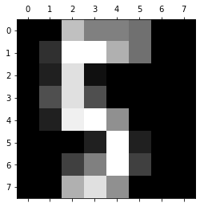

```python
import numpy as np
import pandas as pd
import matplotlib.pyplot as plt
from sklearn.datasets import load_digits
from sklearn.model_selection import train_test_split
%matplotlib inline
digits = load_digits()
plt.gray()
plt.matshow(digits.images[25])
onehot_target = pd.get_dummies(digits.target)
x_train, x_val, y_train, y_val = train_test_split(digits.data, onehot_target, test_size=0.1, random_state=20)
```